# Baseline PD Scorecard

Logistic regression on Weight of Evidence · Flagship PD Model · Stage 2

Author: Chuch · Written with AI assistance

## The short version

0.493test Gini, the scorecard’s discrimination

A transparent scorecard built on **12 applicant fields**, passing all four success criteria set before fitting:

- **Discrimination**: test Gini 0.493, above the 0.45 floor
- **Stability**: train/test gap -0.003, almost none
- **Ranking**: risk rises with every decile, with no reversals

The scorecard is the **champion**. The next deck tests whether a more flexible model finds signal it misses.

## What the model predicts

The model estimates the **probability of payment difficulty** (PD) for each applicant. The target is a payment-difficulty proxy, not a Basel default definition, so the figures describe this dataset’s outcome, not a regulatory default rate.

- Every numeric field is binned, and each bin is replaced by its **Weight of Evidence** (WOE): how much more or less often that bin repays, on a log scale.
- A **logistic regression** combines the WOE values into one score, which converts to a PD.
- Because each field has a fixed, readable table of bins, a decision can be traced back to a specific bin of a specific field.

## Success criteria, set before fitting

| Criterion | Rule |
| --- | --- |
| 1.1a Test Gini | At least 0.45 (floor: EXT_SOURCE_3 alone, 0.36) |
| 1.1b Train/test gap | At most 0.02 |
| 1.1c Coefficients | Signs as credit logic predicts; a significantly wrong sign fails |
| 1.1d Rank ordering | Strictly rising across test deciles, zero reversals |

## Results against the bar

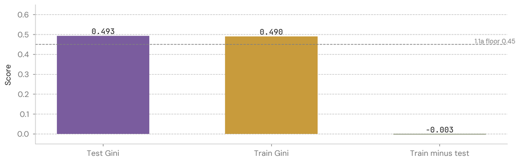

Test KS is 0.362. The base rate is 8.07% in both splits, so the test set is a fair comparison with training.

## Rank ordering: does risk rise with each band?

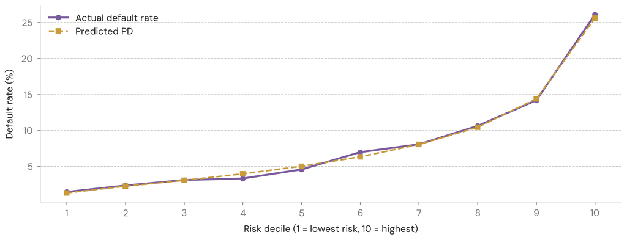

Every decile is riskier than the one before, with **zero reversals** (criterion 1.1d). The two lines show how closely predicted risk tracks the actual rate in each band.

## What drives the score

Each field’s contribution is its WOE multiplied by its coefficient. The table shows the coefficients as fitted.

Logistic regression coefficients, champion scorecard

|  | coefficient |
| --- | --- |
| EXT_SOURCE_3 | -0.825 |
| EXT_SOURCE_2 | -0.752 |
| CREDIT_GOODS | -0.563 |
| NAME_EDUCATION_TYPE | -0.543 |
| EXT_SOURCE_1 | -0.519 |
| ANNUITY_CREDIT | -0.432 |
| ORG_BAND | -0.388 |
| DAYS_EMPLOYED | -0.367 |
| REGION_RATING_CLIENT_W_CITY | -0.352 |
| AMT_GOODS_PRICE | -0.309 |
| OCCUPATION_TYPE | -0.281 |
| NAME_INCOME_TYPE | +0.057 |

The external credit scores carry the most weight, followed by affordability fields. Coefficient signs are checked against credit logic in notebook 02, section 3.3.

## Caveats the committee should hear

- **Target proxy.** The outcome is payment difficulty as recorded in this dataset, not a regulatory default. Results are for comparing approaches, not for pricing.
- **Gender excluded.** CODE_GENDER is a protected attribute and is not a model input. Proxy checks on the retained fields are a next step.
- **Data quality.** Missing external scores are treated as their own bin, because missingness itself carries risk.
- **Illustrative, not production.** This is a portfolio model, not a validated production scorecard.

## Recommendation

**Keep this scorecard as the champion.** It clears all four criteria, is easy to explain field by field, and sets the benchmark the LightGBM challenger has to beat. The challenger’s result is in the next deck.